# Maavärinad

Kerttu-Liis Kõks

mai 2020

### Sissejuhatus

Maavärin on maapinna võnkumine, mida põhjustavad seismilised lained, mis omakorda on põhjustatud litosfääri plokkide liikumisel vabanenud energiast [1]. Lainete teke võib olla nii looduslik kui ka tehislik, looduslikud lained tekivad maa all maavärina epitsentris ning levivad sealt kiiresti eemale ning tehislikult tekitavad laineid näiteks plahvatused. Maavärina võimsust hinnatakse Richteri logaritmilises skaalas -0,3st kuni 9,5ni (seni võimsaim) ning maavärina tagajärgi hinnatakse Mercalli visuaalse skaalaga. Järgnevalt uurimegi ühe maavärinate andmestiku põhjal, kus, kui palju ja millise võimsusega maavärinaid maailmas aset leiab.

### Andmestik

Kasutatud andmestik on võetud Ameerika Ühendriikide Geoloogiateenistuse USGS kodulehelt [2]. Vaadeldud on maavärinaid, mille magnituud oli suurem kui kaks ning mis toimusid ajavahemikul 1970-2019. Algne plaan oli analüüsida viimase saja aasta maavärinaid, kuid andmed selleks pole piisavad, kuna esiteks seati üleilmne seiresüsteem üles 1960ndatel [3] ja maateadlaste kogukond võttis alles omaks laamtektoonika teooria [4]. Seetõttu võib jooniselt 1 ekslikult välja lugeda nagu maavärinate arv kogu aeg kasvaks, tegelikult aga USGS alustas andmete kogumisega 1970ndatel [3] ning enamik sissekandeid on lisatud tagantjärele. Aastatega on täiendatud ka seismojaamade võrku üle maailma, mis on muutnud väiksemate maavärinate registreerimise hõlpsamaks ning üleüldine sündmuste andmebaasidesse kandmine on muutunud efektiivsemaks ning operatiivsemaks. Sellegipoolest on maavärinaid viimase 50 aasta peale kokku 1,19 miljonit, mis olid suurema magnituudiga kui kaks.

Olgu mainitud, et väljaspool USA-d toimuvaid ja magnituudist 4,5 väiksemaid maavärinaid võib USGS-l olla raskem tuvastada, kui pole piisavalt andmeid. USGS võtab mitme kuu jooksul pärast sündmuste toimumist kogu maailma vaatluskeskustest andmeid vastu ning lisab seejärel need andmebaasi. Seetõttu on informatsiooni mujal toimunud kergete maavärinate kohta vähem.

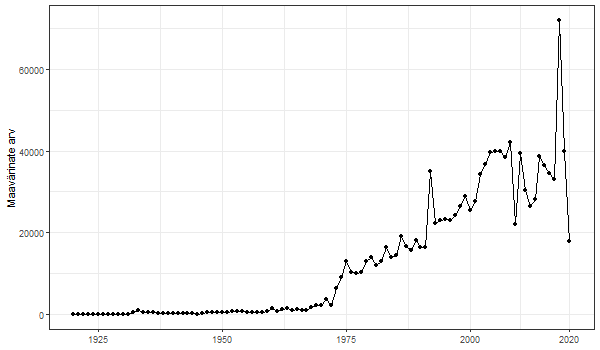

Joonis 1. USGS andmebaasis registreeritud maavärinate arv aastatel 1920-2020.

### Kui tihti ja kui tugevalt maa väriseb?

Õige vastus on loomulikult iga päev ja kogu aeg, aga raske on öelda, mitu maavärinat aastas õieti toimub, sest pole ühtset andmebaasi, mis kajastaks ka kõige väiksemaid maavärinaid ülemaailmselt. Kõige rohkem toimub väikese magnituudiga maavärinaid, üldiselt ei ole tunda maavärinaid, mille magnituud on alla 2,5 [5]. Jooniselt 2 on näha, et viimase 50 aasta peale kokku toimus selliseid maavärinaid 403 tuhat, sellele järgnevad maavärinad magnituudiga kolm ja neli. Maavärinad magnituudiga seitse toimuvad keskmiselt mõned korrad kuus. Magnituudiga 8 ja suuremaid maavärinaid eeldatakse aastas ühel korral, antud andmestikus 50 aasta peale oli suurema magnituudiga kui 8 kokku 40 maavärinat. Joonisel 3 on kujutatud aasta keskmisi magnituude 50 aasta jooksul, kõigi aastate keskmine on 3,34 magnituudi. Joonisel 4 on karpdiagramm magnituudide kohta, magnituudide mediaanväärtus on 3,03, ülemine kvartiil on 4,3 ning alumine kvartiil on 2,37.

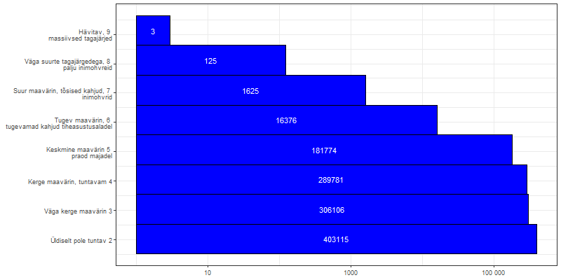

Joonis 2. USGS andmebaasis registreeritud maavärinate koguhulk magnituudide kaupa 1970-2019.

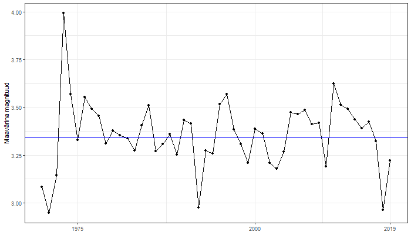

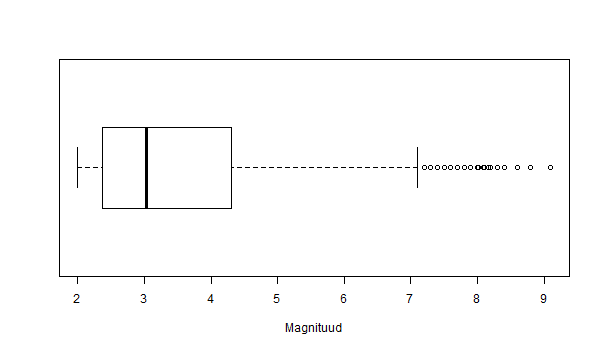

Joonis 4. Magnituudi karpdiagramm

### Kus väriseb maa kõige rohkem?

Maavärinad ei toimu kõikjal võrdselt üle maakera. Peamiselt on maavärinad seotud tektooniliste liikumistega, seetõttu esineb maavärinaid kõige rohkem laamade ehk maakoore plokkide piiridel. Tuntuimad neist on Vaikse ookeani tulerõngas, mis hõlmab ka San Andrease murrangut piki Põhja-Ameerika lääneosa [6]. Teine seismiliselt kõige aktiivsem piirkond on Alpide-Himaalaja mägivöö, mis ulatub Jaava saartest Sumatrani ning läbib Himaalaja mäestikku kuni Atlandi ookeanini välja.

Jooniselt 5 on näha, et väga paljud registreeritud maavärinad on toimunud USA osariikides, millest seismiliselt kõige aktiivsem on California (esindatud erinevates tulpades). Nimelt Californiat läbib San Andrease murrang, mis eraldab Vaikse ookeani ja Põhja-Ameerika laamasid.

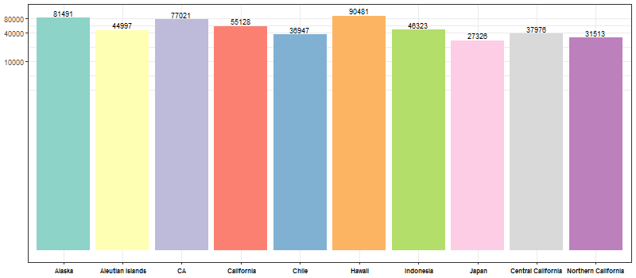

Joonis 5. Kümme enim registreeritud maavärinatega piirkonda ajavahemikus 1970-2019 (kõik magnituudid).

Vaadates maavärinaid, mille magnituud on üle viie, siis avaneb teistsugune vaatepilt. Nimelt ei koosne see nimistu enam peaasjalikult vaid USA osariikidest. Kõige rohkem on toimunud maavärinaid Indoneesias, millele järgneb Jaapan (Japan + Japan region). Kõige rohkem suuri maavärinaid leiab aset seega Vaikse ookeani tulerõngas, eriti selle läänepoolses Aasia osas ja Okeaania saartel.

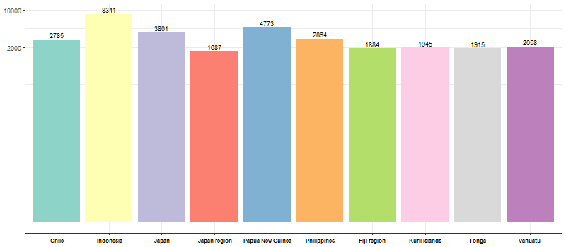

Joonis 6. Kümme enim registreeritud maavärinatega piirkonda 1970-2019 (magnituud > 5).

Tabelis 1 on toodud viimase 50 aasta kõige tugevamad maavärinad ja nende toimumiskoht. 2004. aastal toimunud maavärin Indoneesias Sumatra saarel tõi endaga kaasa hiidlaine ehk tsunami, mis tekitas üüratuid kahjusid. Sama piirkonda tabas uus maavärin juba kolm kuud hiljem uuesti 2005. aasta märtsis, kahjud olid tol korral väiksemad. Üks traagilisemaid oli maavärin 2011. aastal Jaapanis, kus maavärina põhjustatud tsunami tõttu purunes Fukushima tuumaelektrijaam.

Tabel 1. Suurima magnituudiga maavärinad vahemikus 1970-2019 (top 5).

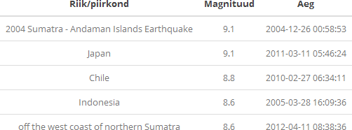

Joonisel 7 kujutatud maailmakaardil on kujutatud maavärinaid viimase 50 aasta jooksul, mis olid suurema magnituudiga kui kuus. Kaardilt joonistub hästi välja eespool mainitud tulerõngas, mis kulgeb piki Ameerika maailmajao lääneosa ja jätkub Vaikse ookeani lääneosas mööda Jaapani rannikut kuni Okeaania saarteni. Punase täpiga on märgitud need maa värisemised, mille magnituud oli üle kaheksa, kokku 40 juhtu.

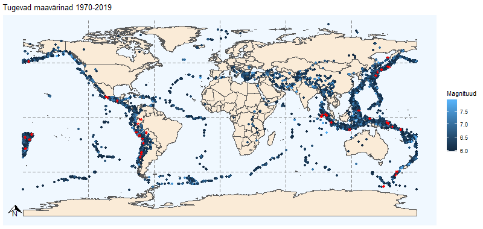

Joonis 7. Maavärinate esinemine (1970-2019), mille magnituud on suurem kui kuus. Punase täpiga on tähistatud maavärinad, mis olid suurema magnituudiga kui kaheksa (40).

### Seosed erinevate näitajate vahel

Joonisel 8 on korrelatsioonimaatriks andmestikus toodud teiste muutujate vahel. Korrelatsioonimaatriksi koostamiseks tuli eemaldada kõik andmeread, kus oli mõni väärtus sisestamata, alles jäi 11,7% esialgsest andmestikust. Maavärina epitsentri sügavuse (depth) ja pikkuskraadi (longitude) vahel on keskmine seos, korrelatsioonikordajaga 0,6. Samuti on keskmine seos (r=0,6) muutujate nst ja magNst vahel, nst näitab mitut seismojaama on kasutatud maavärina asukoha määramiseks ning magNst näitab, mitut seismojaama on kasutatud arvutamaks maavärina magnituudi. Muutuja gap näitab suurimat asimuutilist vahet (kraadides) kahe seismojaama vahel, mida on maavärinate tuvastamiseks kasutatud. Antud muutujal on negatiivses seoses muutujaga nst, mis näitas siis, et mitut jaama asukoha tuvastamisel kasutati.

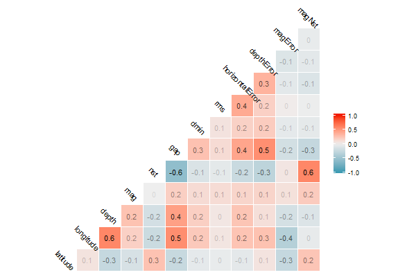

Joonis 8. Korrelatsioonimaatriks erinevate muutujate vahel

### Maavärinad Eestis

Kuigi Eesti asub litosfääri laama keskel, ei tähenda see, et Eestini ei jõuaks maavärinad, seirejaamades tuvastatakse ka tugevamaid kaugemal toimunud maavärinaid, sest seismilised lained liiguvad läbi maakoore. Hetkel teostab Eestis seismoseiret Eesti Geoloogiateenistus (EGT). Lisaks maavärinatele tuvastatakse tehnogeenseid maavärina sündmusi, mille hulgast on võimalik tänu kolmele püsivale seismojaamale tuvastada illegaalseid lõhkamisi [7]. Tabelist 2 selgub, et Eestis on USGS andmebaasis ametlikult registreeritud viis maavärinat, millest tugevaim toimus aastal 1976. Antud maavärin on tuntud kui Osmussaare maavärin [8].

Tabel 2. Eestis registreeritud maavärinad.

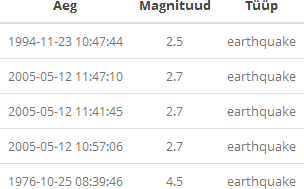

### Huvitavat

Kuigi antud töö keskendus vaid looduslikele maavärinatele, leidus andmestikus ka teisigi maavärina signaali põhjustajaid. Joonisel 9 on välja toodud need muud põhjustajad, mis polnud maavärinad, kuid mis samuti registreeriti andmebaasis 50 viimase aasta jooksul. Kõige rohkem registreeriti karjääride õhkamisi, millele järgnevad niisama plahvatused ja otsesed kaevamistöödega seotud plahvatused. Tabelis 3 aga on näha kuus kõige suurema signaaliga sündmust, kõigi nende ühiseks nimetajaks on tuumakatsetus. Viis võimsamat on Külma sõja aegsed Nõukogude Liidu tuumakatsetused.

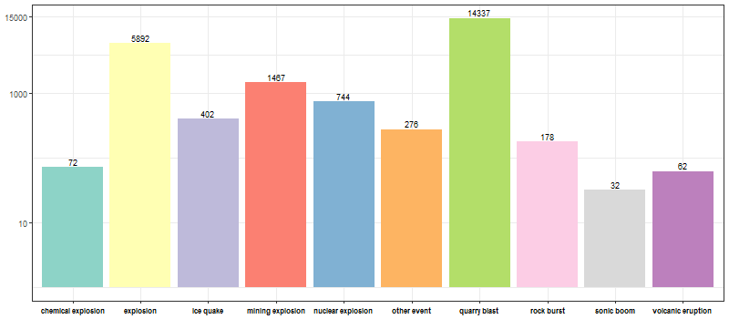

Joonis 9. Teised seismilised sündmused 1970-2019.

Tabel 3. Teised võimsad seismilised sündmused 1970-2019.

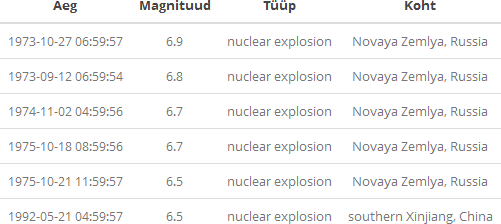

### Kokkuvõte

Maavärinate registreerimine on muutunud lihtsamaks, seirejaamadevõrk on täienenud ning seirekeskused teevad tihedamalt koostööd. Nagu eespool näha, siis maavärinad toimuvad pidevalt, sest litosfääri plokid on pidevas liikumises [9], aga enamikku neist lihtsalt ei tunne. Kõige rohkem toimub seega väikese magnituudiga maavärinaid ja tugevaid väga suurte kahjudega maavärinad toimuvad harva, mõned korrad kuus toimuvad magnituudiga seitse ning paari aasta tagant veelgi tugevamad maavärinad. Kõige rohkem toimub maa värisemist Indoneesias ja Jaapanis ning samuti USA osariigis Californias, ka Eestis on toimunud maavärinaid. Peale maavärinate tuvastatakse ka palju tehnogeenseid sündmusi, mis enamasti on erinevad plahvatused ja lõhkamised.

#### Kasutatud kirjandus

1. https://www.usgs.gov/natural-hazards/earthquake-hazards/science/science-earthquakes?qt-science_center_objects=0#qt-science_center_objects
2. https://earthquake.usgs.gov/earthquakes/search/
3. https://www.usgs.gov/natural-hazards/earthquake-hazards/program-history
4. https://www.sciencelearn.org.nz/resources/1557-earthquakes-timeline
5. http://www.geo.mtu.edu/UPSeis/magnitude.html
6. https://edition.cnn.com/2019/07/06/us/what-is-the-san-andreas-fault-line-trnd/index.html
7. https://www.egt.ee/et/eesmargid-tegevused/seismoseire
8. https://et.wikipedia.org/wiki/Osmussaare_maav%C3%A4rin
9. https://oceanservice.noaa.gov/facts/tectonics.html